# SWNS/BoF Herring MSE MP Testing Results

2024-03-22

# Summary of Results

## Objectives

MSE Objectives  
Conservation Objective  
1. Maintain the stock above the LRP with at least 75% probability in each year in years 10-15 of the projection period for each OM in the reference set.  
Stakeholder Objectives  
2. Maintain SSB above a target biomass in the long-term  
3. Maximize short-term yield  
4. Maximize long-term yield  
5. Minimize variability in catch  
6. Limit the removal of small fish

## Performance Metrics

Minimum Performance Standard for the Conservation Objective

1. P(model estimated SSB > model estimated SSB<sub>2005-2010</sub>) > 0.75 in each year in years 10-15 of the projection period for each OM in the reference set.  
   *Model estimated SSB<sub>2005-2010</sub> = the mean SSB from 2005-2010*  
   *The minimum performance standard is used to eliminate MPs from further consideration*

Performance Metrics

Objective

Metric

Timeframe

2. 1. Maintain SSB above a target biomass in the long-term

P(three-yr moving average acoustic index >425kt)

Years 16-25

2. 2. Maintain SSB above a target biomass in the long term

P(three-yr moving average acoustic index >500kt)

Years 16-25

3. Maximize short-term yield

Average Yield

Years 4-8

4. Maximize long-term yield

Average Yield

Years 6-25

5. Minimize variability in catch

Average inter-annual variability in yield

Years 4-25

6. Limit the removal of small fish

% Small Fish by number (<23 cm)

Years 4-15

*These performance metrics are used to rank the performance of MPs and are not used to eliminate MPs from consideration. Note that 425kt represents a potential target biomass used for ranking the performance of MPs. A target biomass of 500kt is also used to show that the relative ranking of the performance of MPs is the same regardless of the magnitude of the target biomass*

## OMs

### Reference Set

An initial set of OMs was defined as a full factorial cross of the levels of 4 axes of uncertainty:

- Natural Mortality Rate:
  - 1: M = 0.35
  - 2: M = 0.49 (Age 0-2) and 0.26 (Age 3+)
  - 3: M = 0.72 (Age 0-2) and 0.45 (Age 3+)
- Future Growth:
  - A: status quo: mean of last 3 years
  - B: temporal trend: extrapolation of regression of weight at age vs. year
  - Binv: reverse temporal trend: reversal of the magnitude change in weight-at-age in B
- Steepness:
  - H: h = 0.95
  - L: h = 0.65
- Weir catch and size composition data:
  - “-”: exclude weir fleet
  - “+”: include weir fleet

Future recruitment is based on the mean recruitment deviations from 1990-2017.

The reference set of OMs was defined to include the 12 OMs with natural mortality rate level 1: M = 0.35

| OM | M | Growth | Steepness | Weir |
| --- | --- | --- | --- | --- |
| 1 | 1 | A | 0.95 | $-$ |
| 4 | 1 | B | 0.95 | $-$ |
| 7 | 1 | A | 0.65 | $-$ |
| 10 | 1 | B | 0.65 | $-$ |
| 13 | 1 | A | 0.95 | $+$ |
| 16 | 1 | B | 0.95 | $+$ |
| 19 | 1 | A | 0.65 | $+$ |
| 22 | 1 | B | 0.65 | $+$ |
| 25 | 1 | Binv | 0.95 | $-$ |
| 28 | 1 | Binv | 0.65 | $-$ |
| 31 | 1 | Binv | 0.95 | $+$ |
| 34 | 1 | Binv | 0.65 | $+$ |

### Robustness Set 1

An initial set of OMs was defined as a full factorial cross of the levels of 4 axes of uncertainty:

- Natural Mortality Rate:
  - 1: M = 0.35
  - 2: M = 0.49 (Age 0-2) and 0.26 (Age 3+)
  - 3: M = 0.72 (Age 0-2) and 0.45 (Age 3+)
- Future Growth:
  - A: status quo: mean of last 3 years
  - B: temporal trend: extrapolation of regression of weight at age vs. year
  - Binv: reverse temporal trend: reversal of the magnitude change in weight-at-age in B
- Steepness:
  - H: h = 0.95
  - L: h = 0.65
- Weir catch and size composition data:
  - “-”: exclude weir fleet
  - “+”: include weir fleet

Future recruitment is based on the mean recruitment deviations from 1990-2017.

The first set of robustness OMs consists of the OMs with natural mortality rate level 2 and 3 that converged. OMs 20, 23, and 35 did not converge.

| OM | M | Growth | Steepness | Weir |
| --- | --- | --- | --- | --- |
| 2 | 2 | A | 0.95 | $-$ |
| 3 | 3 | A | 0.95 | $-$ |
| 5 | 2 | B | 0.95 | $-$ |
| 6 | 3 | B | 0.95 | $-$ |
| 8 | 2 | A | 0.65 | $-$ |
| 9 | 3 | A | 0.65 | $-$ |
| 11 | 2 | B | 0.65 | $-$ |
| 12 | 3 | B | 0.65 | $-$ |
| 14 | 2 | A | 0.95 | $+$ |
| 15 | 3 | A | 0.95 | $+$ |
| 17 | 2 | B | 0.95 | $+$ |
| 18 | 3 | B | 0.95 | $+$ |
| 21 | 3 | A | 0.65 | $+$ |
| 24 | 3 | B | 0.65 | $+$ |
| 26 | 2 | Binv | 0.95 | $-$ |
| 27 | 3 | Binv | 0.95 | $-$ |
| 29 | 2 | Binv | 0.65 | $-$ |
| 30 | 3 | Binv | 0.65 | $-$ |
| 32 | 2 | Binv | 0.95 | $+$ |
| 33 | 3 | Binv | 0.95 | $+$ |
| 36 | 3 | Binv | 0.65 | $+$ |

### Robustness Set 2

A set of OMs was defined from these uncertainties:

- Natural Mortality Rate:
  - 1: M = 0.35
- Future Growth:
  - B: temporal trend: extrapolation of regression of weight at age vs. year
  - Binv: reverse temporal trend: reversal of the magnitude change in weight-at-age in B
- Steepness:
  - H: h = 0.95
  - L: h = 0.65
- Weir catch and size composition data:
  - “-”: exclude weir fleet
  - “+”: include weir fleet
- Future recruitment
  - 90-17: future recruitment based on mean recruitment deviations from 1990-2017 (from reference set assumption)
  - 68-17: future recruitment based on mean recruitment deviations from 1968-2017
  - 90%: future recruitment based on the lower 90% of historical recruitment deviations

| OM | M | Growth | Steepness | Weir | Recruitment | Weir_future_catch |
| --- | --- | --- | --- | --- | --- | --- |
| R1a | 1 | Binv | 0.95 | $-$ | 68-17 | 20% SWNS/BoF TAC |
| R1b | 1 | B | 0.65 | $-$ | 68-17 | 20% SWNS/BoF TAC |
| R1c | 1 | Binv | 0.95 | $+$ | 68-17 | 20% SWNS/BoF TAC |
| R1d | 1 | B | 0.65 | $+$ | 68-17 | 20% SWNS/BoF TAC |
| R2a | 1 | Binv | 0.95 | $-$ | 90% | 20% SWNS/BoF TAC |
| R2b | 1 | B | 0.65 | $-$ | 90% | 20% SWNS/BoF TAC |
| R2c | 1 | Binv | 0.95 | $+$ | 90% | 20% SWNS/BoF TAC |
| R2d | 1 | B | 0.65 | $+$ | 90% | 20% SWNS/BoF TAC |
| R3a | 1 | Binv | 0.95 | $-$ | 90-17 | 40% SWNS/BoF TAC |
| R3b | 1 | B | 0.65 | $-$ | 90-17 | 40% SWNS/BoF TAC |
| R3c | 1 | Binv | 0.95 | $+$ | 90-17 | 40% SWNS/BoF TAC |
| R3d | 1 | B | 0.65 | $+$ | 90-17 | 40% SWNS/BoF TAC |
| R4a | 1 | Binv | 0.95 | $-$ | 90-17 | 50% SWNS/BoF TAC |
| R4b | 1 | B | 0.65 | $-$ | 90-17 | 50% SWNS/BoF TAC |
| R4c | 1 | Binv | 0.95 | $+$ | 90-17 | 50% SWNS/BoF TAC |
| R4d | 1 | B | 0.65 | $+$ | 90-17 | 50% SWNS/BoF TAC |
| R5a | 1 | Binv | 0.95 | $-$ | 90-17 | 60% SWNS/BoF TAC |
| R5b | 1 | B | 0.65 | $-$ | 90-17 | 60% SWNS/BoF TAC |
| R5c | 1 | Binv | 0.95 | $+$ | 90-17 | 60% SWNS/BoF TAC |
| R5d | 1 | B | 0.65 | $+$ | 90-17 | 60% SWNS/BoF TAC |

## MPs

### Description

Plots for some MPs can be found on the Google Drive. However, see MP Testing, sub-tab Projection plots, for potential future catches if a selected MP was implemented. Aside from NRef, actual catch removals were implemented for 2021 and 2022, and the 2022 acoustic index is used for catch implementation for projection year 3 for the closed-loop simulations.

| MP | Description |
| --- | --- |
| fix13.2_FY23 | custom |
| HS_1.8_5.8_200_425a | hockey stick - annual acoustic index |
| HS_PA_8.1a | hockey stick -annual acoustic index - precautionary under the LRP |
| nALT_f11_d100_u20_3sq | custom |
| nALT_f11_d100_u20_3sq_mod10 | custom |
| nALT_f11_d7_35_7u20 | custom |
| nALT_f11_d7_35_7u20_3sq | custom |
| NFref_FY23 | Catch removals counted, F=0 reference after fishing year 2023 |
| P3.4a | custom |
| P4.4a | 4.4% harvest rate - annual acoustic index |
| P4.5s | 4.5% harvest rate - 3-year acoustic index |
| P4.8a_20_80 | 4.8% harvest rate - annual acoustic index; 20% juv PS TAC |

## MP Testing

### Reference Set

#### Pass/Fail Performance

Minimum Performance Standard Performance:  
P(Model estimated SSB > Model estimated SSB<sub>2005-2010</sub>) > 0.75 in each year in years 10-15 of the projection period for each OM in the reference set.

| Pass | Fail |
| --- | --- |
| NFref | nALT_f11_d100_u20_3sq |
| fix13.2_FY23 | nALT_f11_d7_35_7u20_3sq |
| HS_1.8_5.8_200_425a |  |
| HS_PA_8.1a |  |
| nALT_f11_d100_u20_3sq_mod10 |  |
| nALT_f11_d7_35_7u20 |  |
| NFref_FY23 |  |
| P3.4a |  |
| P4.4a |  |
| P4.5s |  |
| P4.8a_20_80 |  |

##### Objective 1 Boxplots

###### Passing MPs

Boxplot = distribution of values in the reference set of OMs.  
Box = 25<sup>th</sup>, 50<sup>th</sup>, and 75<sup>th</sup> percentiles Whiskers = min and max, extreme values plotted as individual points

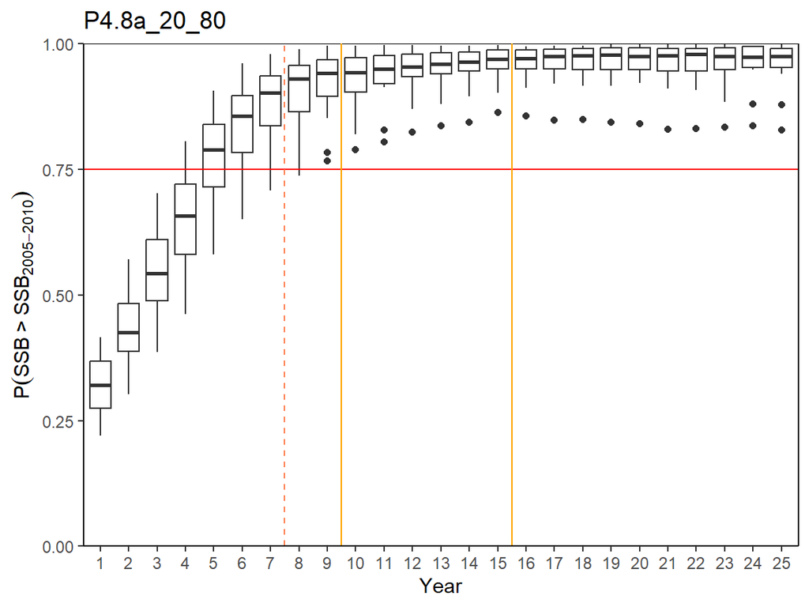

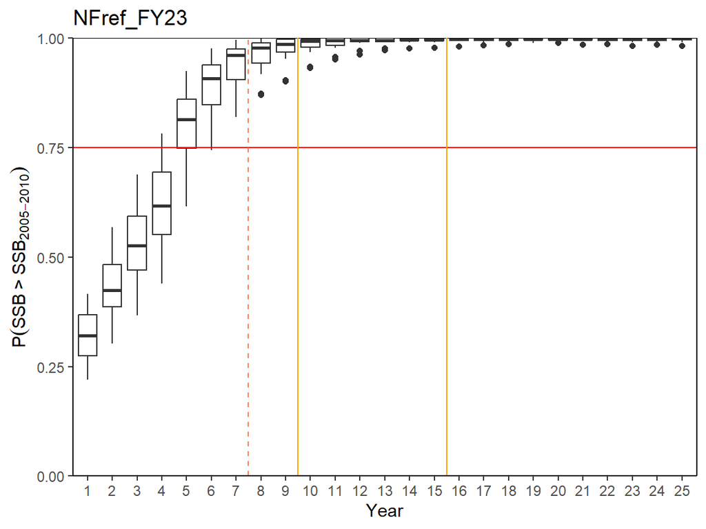

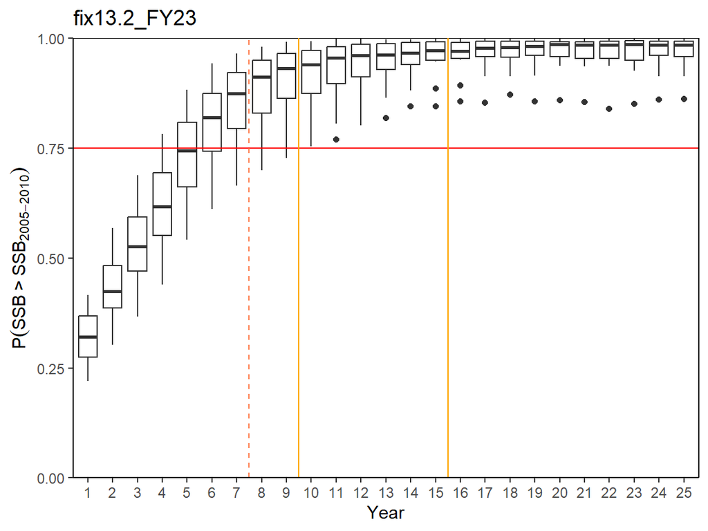

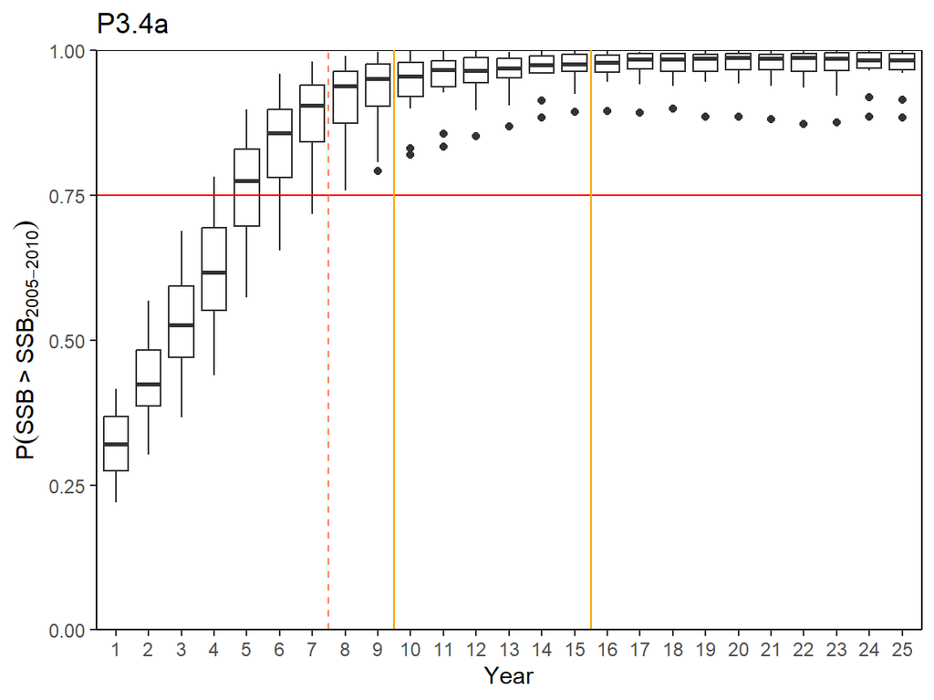

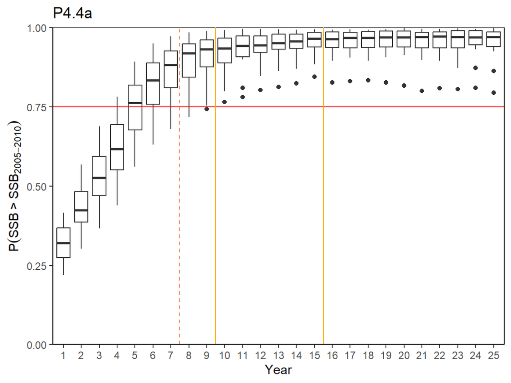

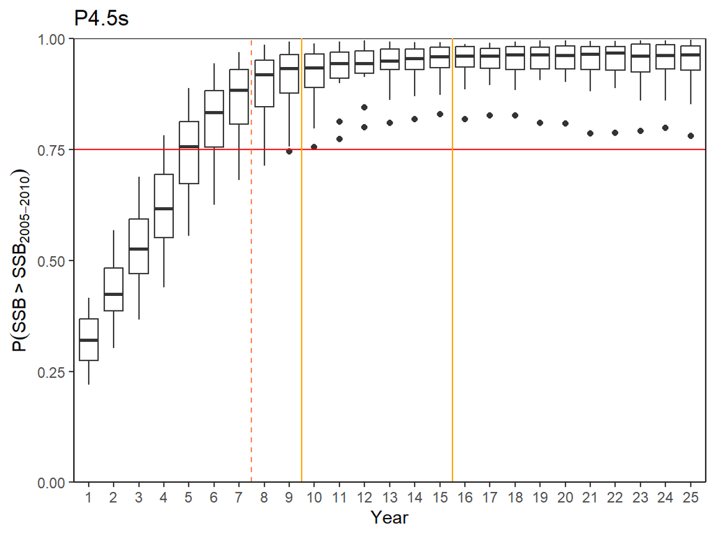

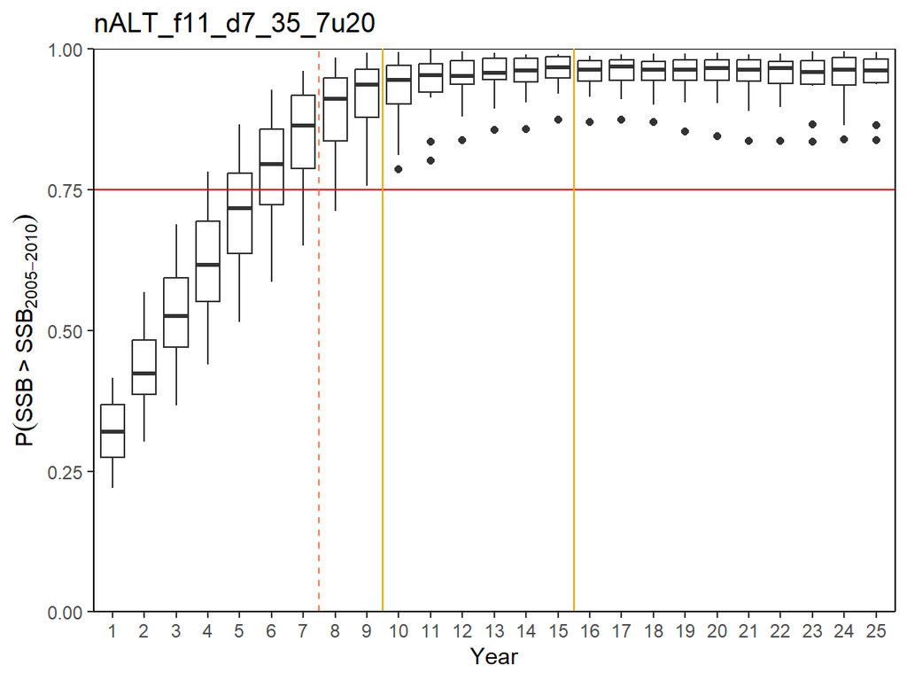

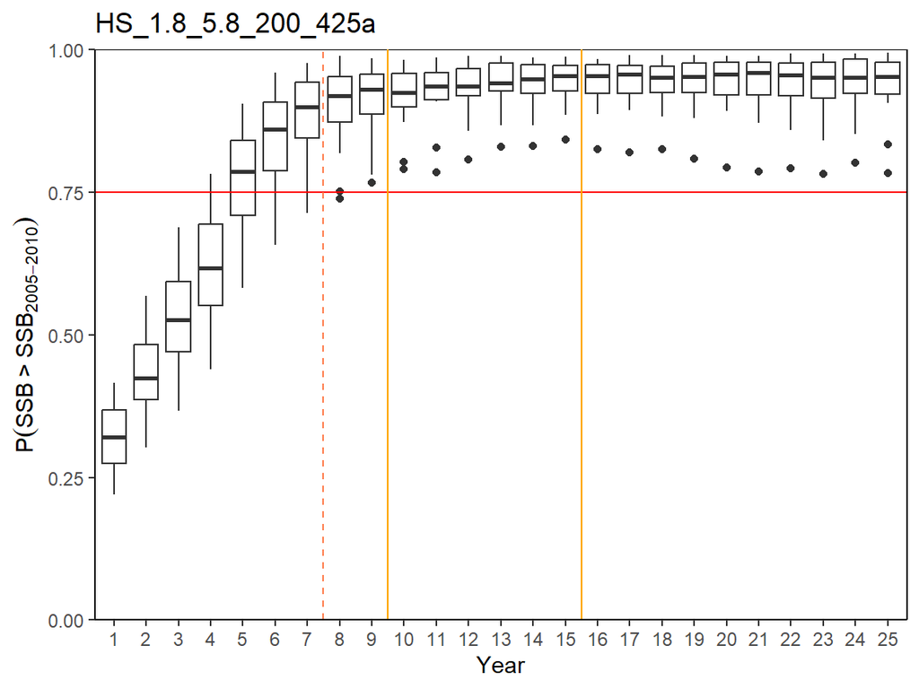

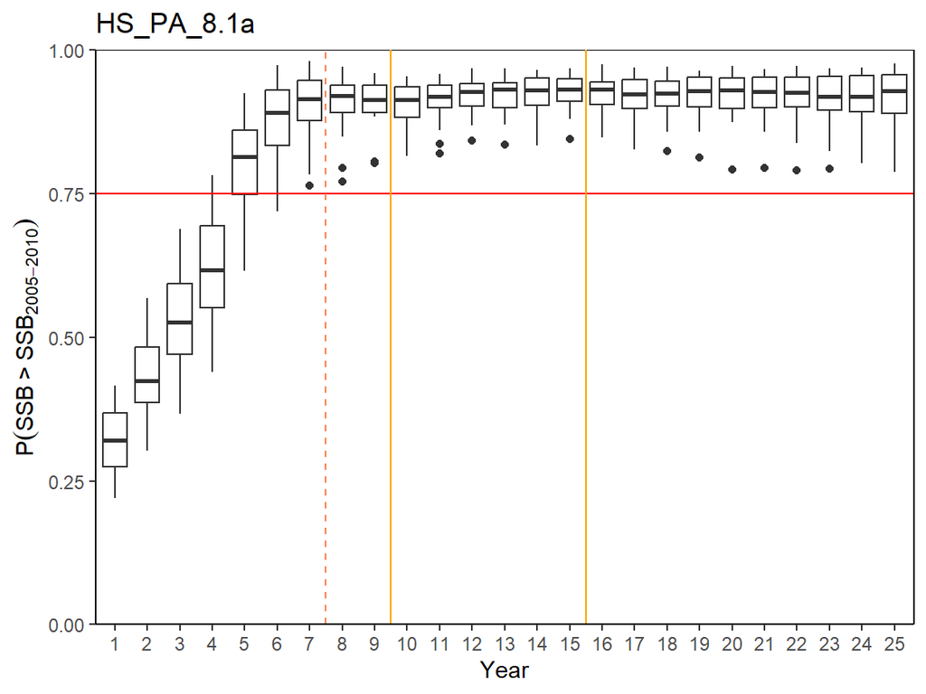

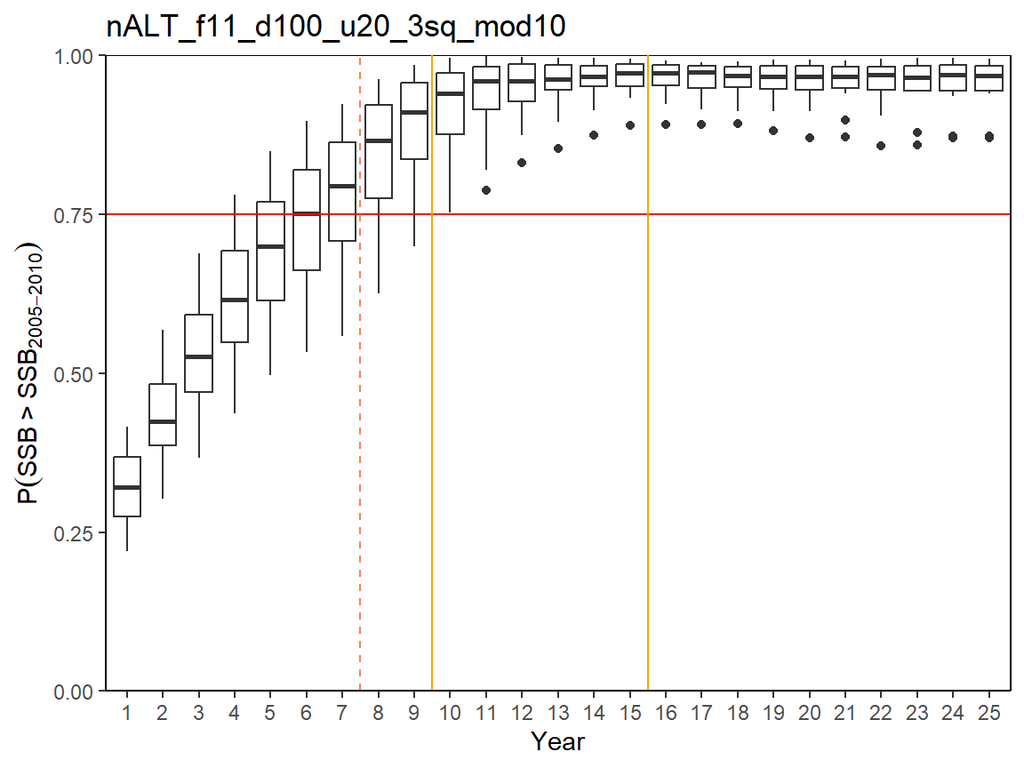

###### Failing MPs

Boxplot = distribution of values in the reference set of OMs.  
Box = 25<sup>th</sup>, 50<sup>th</sup>, and 75<sup>th</sup> percentiles Whiskers = min and max, extreme values plotted as individual points

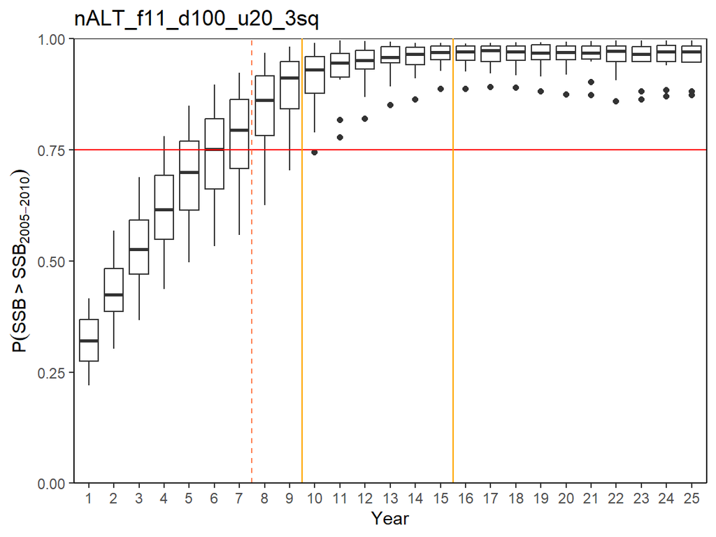

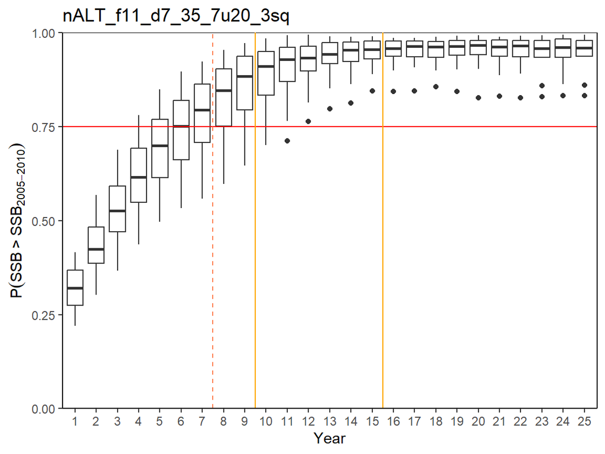

##### Objective 1 Dotplots

###### Passing MPs

Symbols and Colours on dotplots indicate axis of uncertainy across OMs. Black excludes weir fleet landings. Red includes landings. Triangle indicates high steepness and circle indicates low steepness in the stock recruitment relationship.

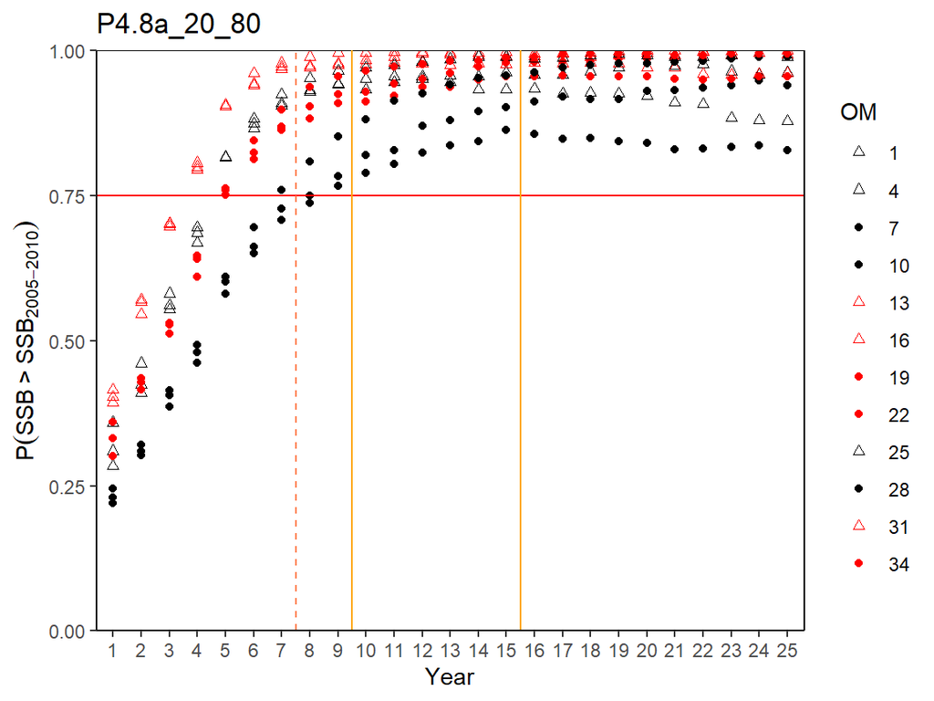

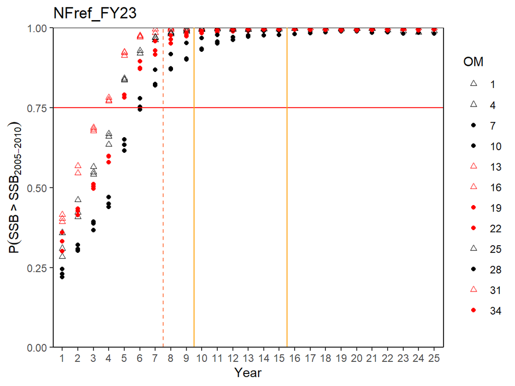

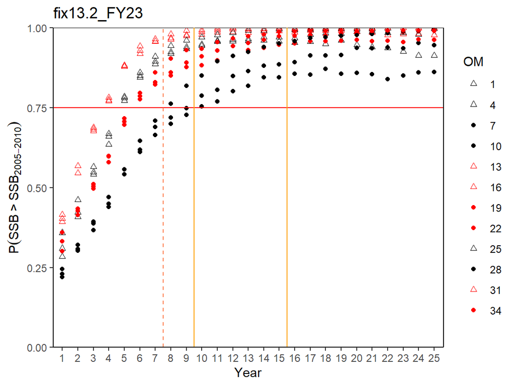

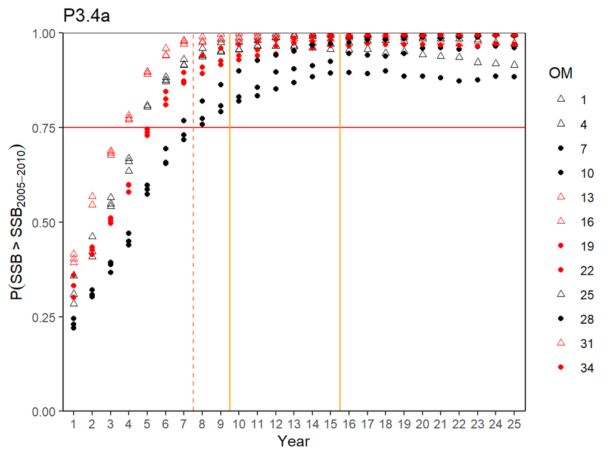

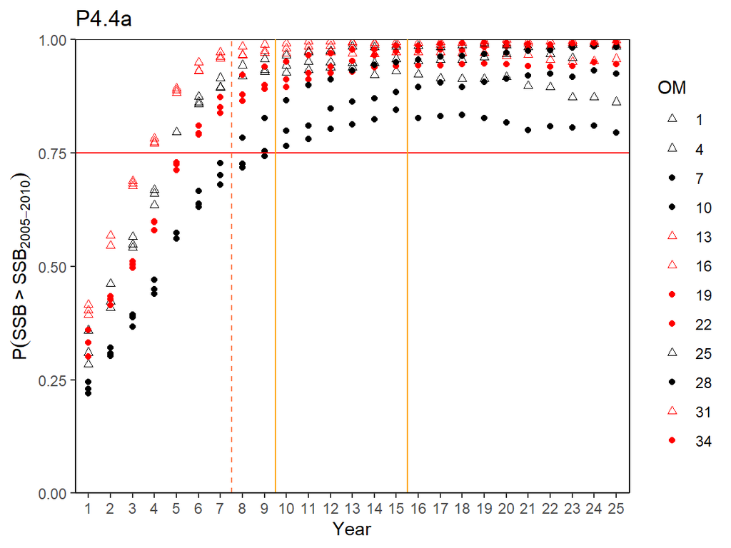

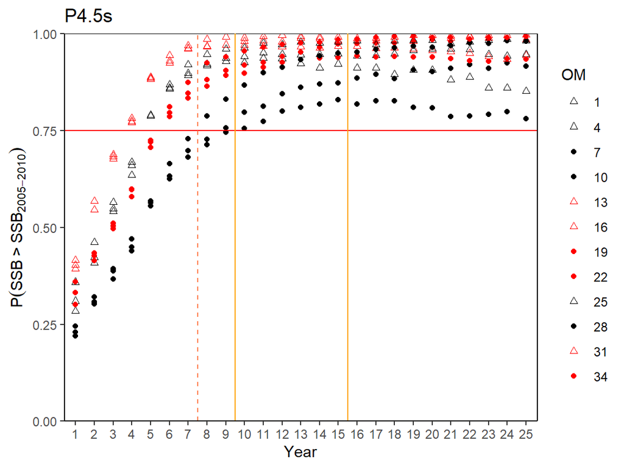

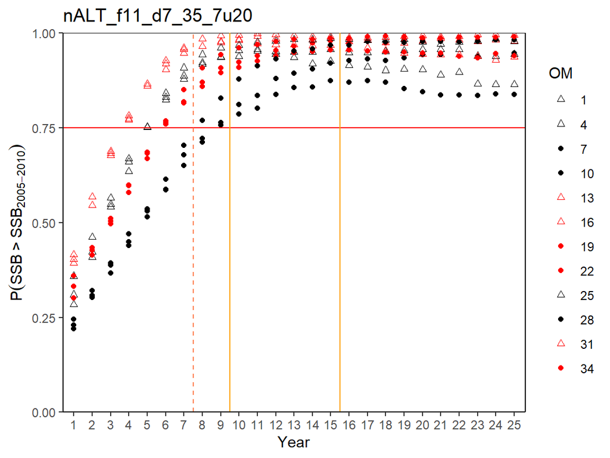

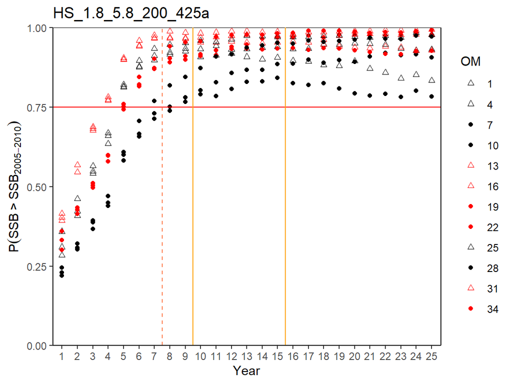

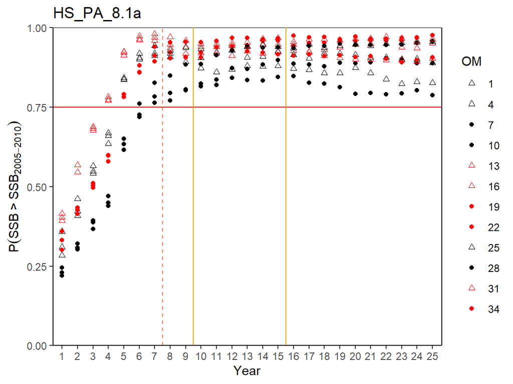

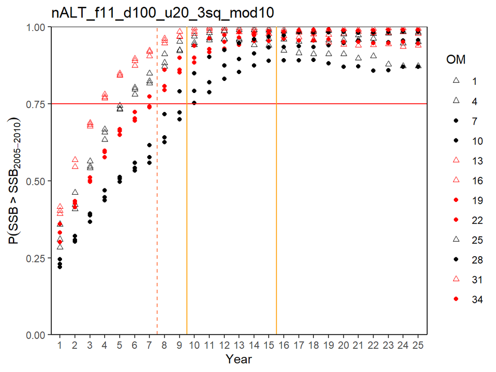

###### Failing MPs

Symbols and Colours on dotplots indicate axis of uncertainy across OMs. Black excludes weir fleet landings. Red includes landings. Triangle indicates high steepness and circle indicates low steepness in the stock recruitment relationship.

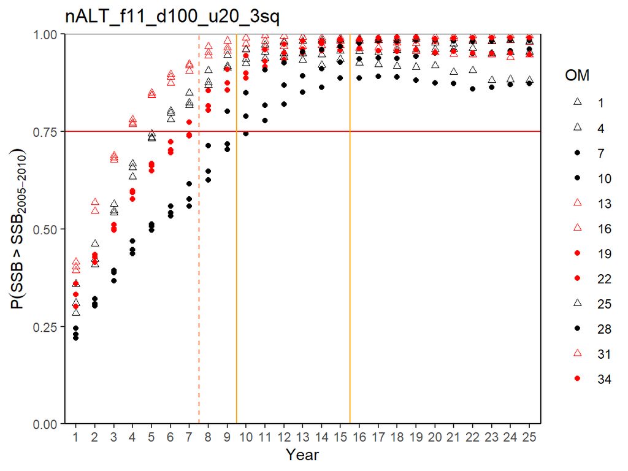

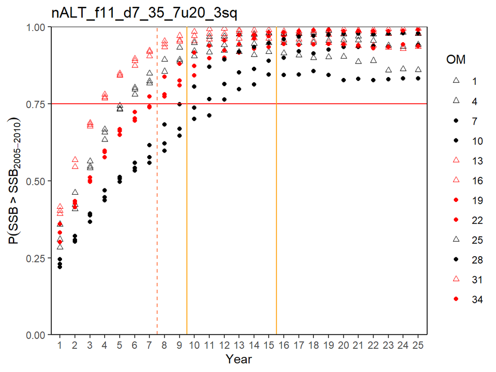

##### T<sub>min</sub>

T<sub>min</sub> is defined as the time to rebuild above a rebuilding target when no fishing occurs. For SWNS/BoF, the rebuilding target is objective 1: P(Model estimated SSB > Model estimated SSB<sub>2005-2010</sub>) > 0.75 in each year in years 10-15 of the projection period for each OM in the reference set.  
Notes  
Tmin is calculated for each OM individually.  
Since fishing occurred in 2021, 2022, and 2023 Tmin was calculated using projection year 4 (2024) as the first year of rebuilding.

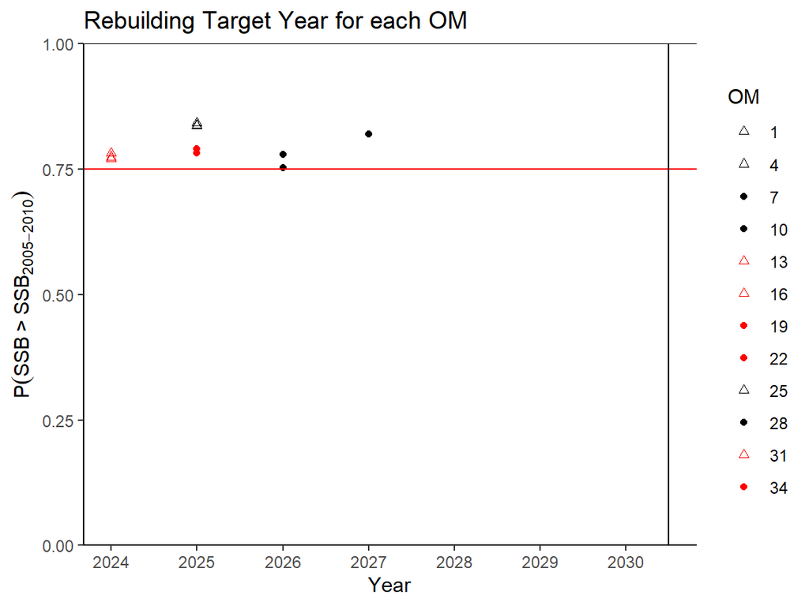

| OM | Tmin in Years | P(SSB<sub>></sub>SSB<sub>2005-2010</sub>) |
| --- | --- | --- |
| 1 | 1 | 84.2 |
| 4 | 1 | 83.6 |
| 7 | 2 | 75.3 |
| 10 | 3 | 82.0 |
| 13 | 0 | 77.4 |
| 16 | 0 | 78.2 |
| 19 | 1 | 78.1 |
| 22 | 1 | 79.0 |
| 25 | 1 | 83.8 |
| 28 | 2 | 77.9 |
| 31 | 0 | 77.0 |
| 34 | 1 | 78.1 |

#### Projection Plots

##### SSB

###### Passing MPs

Thick black line = median across all simulations  
Grey shading = 10<sup>th</sup>, 25<sup>th</sup>, 75<sup>th</sup>, and 90<sup>th</sup> percentiles across all simulations

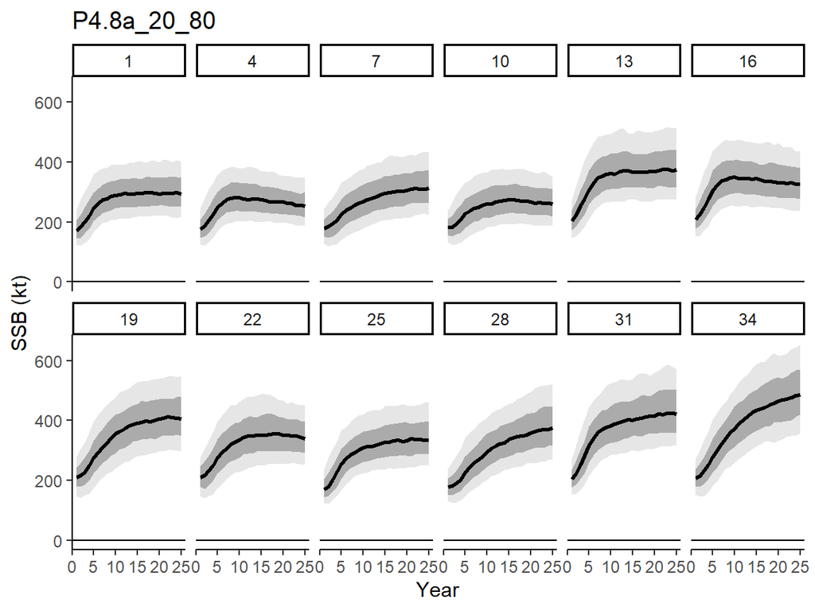

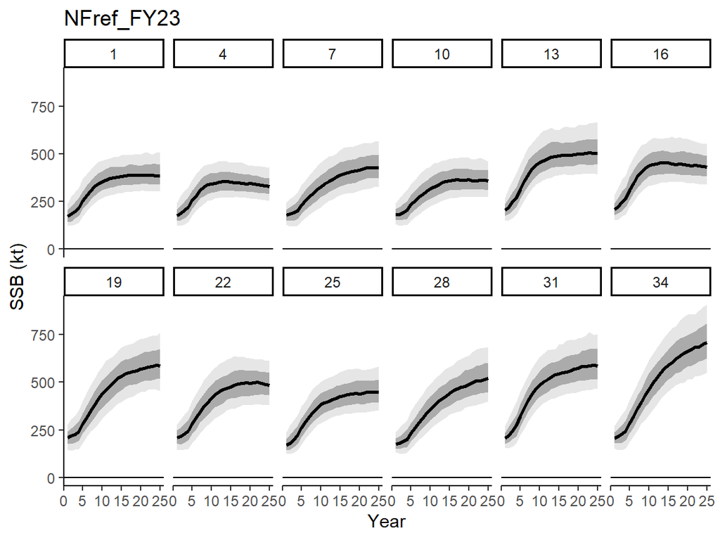

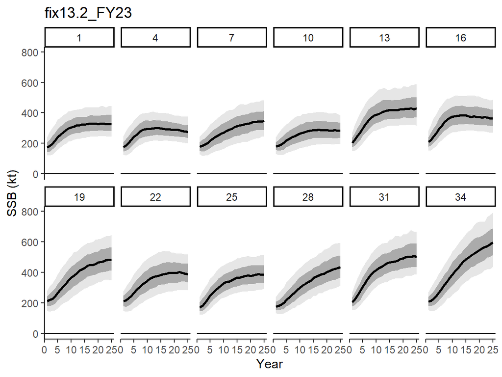

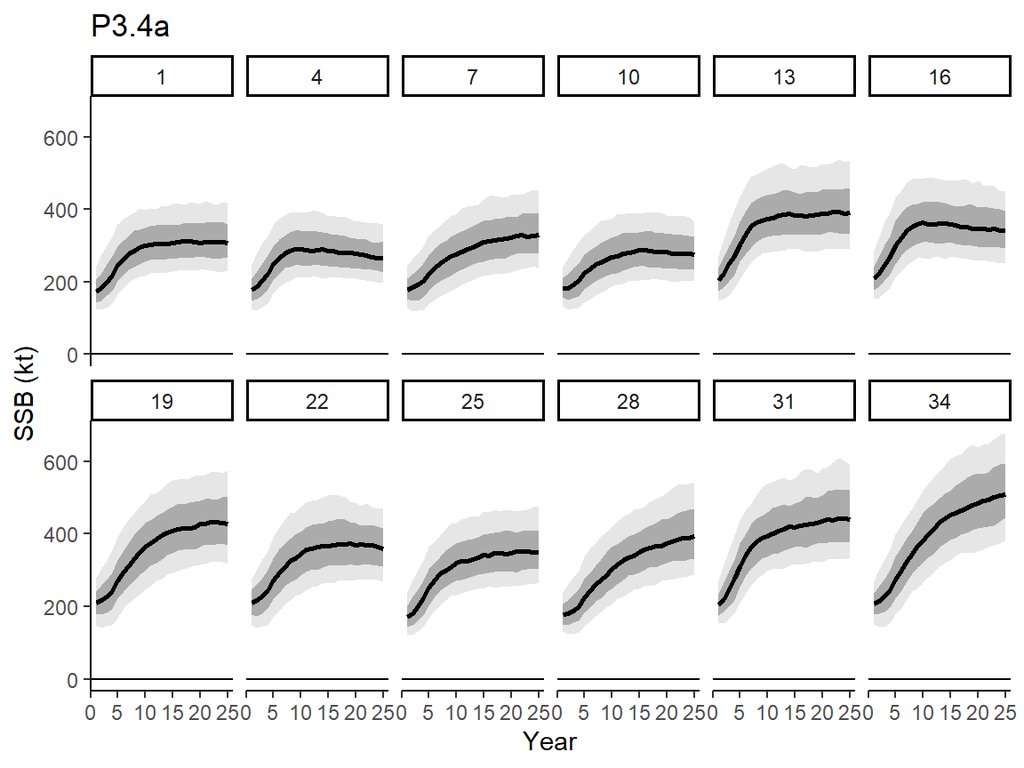

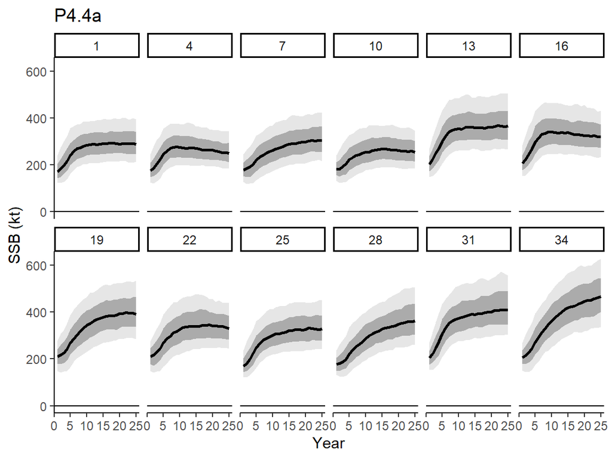